# Homework 1 - Group K

Bougammoura, Santacatterina, Di Tommaso, Sicklinger

## Exercise 1.1

Let $X\ge 0$ be an exponential random variable with p.d.f. $f(x)=\lambda\exp(-\lambda x)$.

1. The c.d.f. of $X$ is the function $F$ such that $F(x)=Pr(x\le x)$. For the values $x\ge 0$ we have
   $$F(x)=\int_0^x f(x')dx'=\int_0^x \lambda\exp(-\lambda x')dx'=1-\exp(-\lambda x),$$
   whereas, for $x<0$,
   $$F(x)=0.$$

2. We calculate the $Pr(X\le \lambda)$ using the p.d.f.:

$$Pr(X\le\lambda)=\int_0^{\lambda}f(x)dx=\int_0^{\lambda}\lambda\exp(-\lambda x)dx=1-\exp(-\lambda^2).$$

The median of $X$ is the quantile of order 1/2, hence:

$$\text{Median}(X) = Q(0.5 ; \lambda) = -\frac{\text{ln}(1/2)}{\lambda} = \frac{\text{ln}(2)}{\lambda}$$

3. The mean of $X$ is given by
   $$E[X]=\int_{[0,+\infty)}xf(x)dx=\lambda\int_{[0,+\infty)}x\exp(-\lambda x)dx=-\lambda\frac{d}{d\lambda}\int_{[0,+\infty)}\exp(-\lambda x)dx=-\lambda\frac{d}{d\lambda}\frac{1}{\lambda}=\frac{1}{\lambda}.$$
   The variance of $X$ is
   $$VAR[X]=E[X^2]-(E[X])^2=\lambda\int_{[0,+\infty)}x^2\exp(-\lambda x)dx-\frac{1}{\lambda^2},$$
   where
   $$\int_{[0,+\infty)}x^2\exp(-\lambda x)dx=\frac{d^2}{d\lambda^2}\int_{[0,+\infty)}\exp(-\lambda x)dx=\frac{d^2}{d\lambda^2}\frac{1}{\lambda}=\frac{2}{\lambda^3},$$
   so that we get
   $$VAR[X]=\lambda\frac{2}{\lambda^3}-\frac{1}{\lambda^2}=\frac{1}{\lambda^2}.$$

## Exercise 1.2

Evaluate $Pr(X < 0.5, Y < 0.5)$ if $X$ and $Y$ have joint p.d.f. $f(x,y) = x + 3/2 y^2$.

We need to solve the C.D.F. of $(X,Y)$ from 0 to 0.5:
$$Pr(X < 0.5, Y < 0.5) = \int_0^{\tfrac{1}{2}}\int_0^{\tfrac{1}{2}}(x + \tfrac{3}{2}y^2)\,dx\,dy$$
Solving the integral for $dx$:
$$\int_0^{\tfrac{1}{2}}(x + \tfrac{3}{2}y^2)\,dx= \tfrac{x^2}{2} + \tfrac{3}{2}y^2 \Big|_0^{\tfrac{1}{2}}=\tfrac{1}{8}+\tfrac{3}{4}y^2$$
Now, solving for $dy$:
$$\int_0^{\tfrac{1}{2}}(\tfrac{1}{8}+\tfrac{3}{4}y^2)\,dy= \tfrac{y}{8}+\tfrac{y^3}{4}\Big|_0^{\tfrac{1}{2}}=\tfrac{1}{16}+\tfrac{1}{32}=\tfrac{3}{32}$$

## Exercise 1.6

Let X, Y be two non-independent random variables, with $VAR[X]=\sigma_x^2$, $VAR[Y]=\sigma_y^2$ and $COV[X,Y]=\sigma_{xy}^2$. The covariance matrix of
$$\mathbf{X}=\begin{bmatrix}
X\\
Y
\end{bmatrix}$$
is
$$\mathbf{\Sigma}=\begin{bmatrix}
\sigma_x^2 & \sigma_{xy}^2\\
\sigma_{xy}^2 & \sigma_y^2
\end{bmatrix}.$$
From the results of section $1.6.2$ we know that the transformed vector
$$\mathbf{a}^T\mathbf{X}$$
has variance $\mathbf{a}^T\mathbf{\Sigma}\mathbf{a}$ We define
$$\mathbf{a_1}=\begin{bmatrix}
1\\
1
\end{bmatrix},\,\,\,\mathbf{a_2}=\begin{bmatrix}
1\\
-1
\end{bmatrix}.$$
Therefore, we obtain
$$VAR[X+Y]=\mathbf{a_1}^T\mathbf{\Sigma}\mathbf{a_1}=\begin{bmatrix}
1&1\\
\end{bmatrix}\begin{bmatrix}
\sigma_x^2 & \sigma_{xy}^2\\
\sigma_{xy}^2 & \sigma_y^2
\end{bmatrix}\begin{bmatrix}
1\\
1
\end{bmatrix}=\begin{bmatrix}
1&1\\
\end{bmatrix}\begin{bmatrix}
\sigma_x^2+\sigma_{xy}^2\\
\sigma_{xy}^2+\sigma_y^2
\end{bmatrix}=\sigma_x^2+\sigma_y^2+2\sigma_{xy}^2,$$
and
$$VAR[X-Y]=\mathbf{a_2}^T\mathbf{\Sigma}\mathbf{a_2}=\begin{bmatrix}
1&-1\\
\end{bmatrix}\begin{bmatrix}
\sigma_x^2 & \sigma_{xy}^2\\
\sigma_{xy}^2 & \sigma_y^2
\end{bmatrix}\begin{bmatrix}
1\\
-1
\end{bmatrix}=\begin{bmatrix}
1&-1\\
\end{bmatrix}\begin{bmatrix}
\sigma_x^2-\sigma_{xy}^2\\
\sigma_{xy}^2-\sigma_y^2
\end{bmatrix}=\sigma_x^2+\sigma_y^2-2\sigma_{xy}^2.$$

## Exercise 1.8

If $log(X)\sim N(\mu,\sigma^2)$, find the p.d.f of $X$.

We can write $log(X)=Y$ and so $Y\sim N(\mu,\sigma^2)$. We define $f_{Z}$ and $f_{X}$ probability density functions of $Z$ and $X$, respectively; where $Z =\frac{log(X)-\mu}{\sigma} \sim N(0,1)$. $F_Z$ and $F_X$ are cumulative density functions of $Z$ and $X$. Then:
$$f_X(x) = \frac{d}{dx} (F_X(x))=\frac{d}{dx}Pr \{log(X)\le log(x) \}$$
Using the standardized variable $Z$, we can write:
$$\frac{d}{dx}Pr \{log(X)\le log(x) \}=\frac{d}{dx}\Big(Pr\Big\{\frac{log(X)-\mu}{\sigma}\le\frac{log(x)-\mu}{\sigma}\Big\}\Big)$$
Thus:
$$\frac{d}{dx}F_N\Big(\frac{log(X)-\mu}{\sigma}\Big)=F'_N\Big(\frac{log(X)-\mu}{\sigma}\Big)\times\frac{d}{dx}\Big(\frac{log(X)-\mu}{\sigma}\Big)$$
So:
$$f_X(x)=\frac{1}{\sqrt{2\pi}}\times\frac{1}{\sigma}\times\frac{1}{x}\times exp{\Big(-\frac{1}{\sqrt{2\pi}}\Big(\frac{log(X)-\mu}{\sigma}\Big)^2\Big)}$$

## Exercise 3.3

Code from the exercise written as a function so as to apply the function system.time:

```r
code <- function(z) {
  zneg <- 0; j <- 1
  for (i in 1:100000) {
    if (z[i] < 0) {
      zneg[j] <- z[i]
      j <- j+1
    }
  }
  return(length(zneg))
}
z<-rnorm(100000) #defined outside the function so that it is taken as input for zneg2
code(z)
```

```
## [1] 50123
```

```r
system.time(code(z))
```

```
##    user  system elapsed
##   0.023   0.000   0.023
```

Code with loop replaced:

```r
system.time(zneg2 <- z[z<0])
```

```
##    user  system elapsed
##   0.001   0.000   0.001
```

```r
length(zneg2)
```

```
## [1] 50123
```

## Exercise 3.5

We consider the problem of solving the linear system $\mathbf{A}\mathbf{x}=\mathbf{y}$, where $\mathbf{A}$ and $\mathbf{y}$ are known. We solve it in two ways, the first by inverting $\mathbf{A}$ first and then computing $\mathbf{x}=\mathbf{A}^{-1}\mathbf{y}$ and the second by solving it directly. We create $\mathbf{A}$, $\mathbf{y}$ and the exact vector $\mathbf{x}$ which satisfy $\mathbf{A}\mathbf{x}=\mathbf{y}$:

```r
set.seed(0); n <- 1000
A <- matrix(runif(n*n),n,n); x.true <- runif(n)
y <- A%*%x.true
```

1. We use `solve` to compute $\mathbf{A}^{-1}$ first, the we find the solution as $\mathbf{x_1}=\mathbf{A}^{-1}\mathbf{y}$ and we ask for the time needed to perform the computation `sys.t.1`:

```r
sys.t.1 <- system.time(x.1 <- solve(A)%*%y)
sys.t.1
```

```
##    user  system elapsed
##   0.815   0.012   0.826
```

The we compute the mean absolute difference between `x.true` and `x.1` as:

```r
d.1 <- abs(x.true-x.1)
mean.1 <- mean(d.1)
mean.1
```

```
## [1] 2.956833e-11
```

2. We now solve the linear system directly using `solve`, asking again for the time needed to perform the computation:

```r
sys.2 <- system.time(x.2 <- solve(A,y))
sys.2
```

```
##    user  system elapsed
##   0.236   0.000   0.236
```

The we compute the mean absolute difference between between `x.true` and `x.2` as:

```r
d.2 <- abs(x.true-x.2)
mean.2 <- mean(d.2)
mean.2
```

```
## [1] 1.356142e-12
```

We can conclude by saying that solving the linear system $\mathbf{A}\mathbf{x}=\mathbf{y}$ using the function `solve(A,y)` is much faster and accurate than computing the inverse of $\mathbf{A}$, `solve(A)`, first and then perform $\mathbf{A}^{-1}\mathbf{y}$ to get the solution.

## Exercise 3.6

```r
# R function that takes a vector of unordered observations x
# and returns the values of the empirical c.d.f for each value,
# in the order corresponding to the original vector x

empirical_cdf <- function(x, plot.cdf = F){
  # We initialize a vector that will contain the values of the
  # empirical c.d.f.
  cdf_values = vector(mode = "numeric", length = length(x))

  # First of all, we order the values in x in ascending order
  x_ord = sort.int(x)

  n = length(x)
  i = 1

  # We loop over every index of the vector x
  while (i <= n) {
    # val is the observation at index i
    val = x[i]
    # the cdf value of index i will be equal to (j-1) / n,
    # where j is the index in the ordered x vector corresponding
    # to the observation of index i
    #j = match(val, x_ord)
    #cdf_values[i] = (j - 1) / n

    # if we consider the <= we have
    j = max(which(x_ord %in% val))
    cdf_values[i] = j/n

    # we increase i by one
    i = i + 1
  }

  if(plot.cdf){
    # in order to plot a better graph we
    cdf_ord = sort.int(cdf_values)
    plot(x_ord, cdf_ord, type = "s", ylim = c(0,1), col = 4,
         xlab = "x", ylab = "F(x)", main = "Empirical distribution function")
  }

  return(cdf_values)
}
```

Test with both normal and uniform distribution:

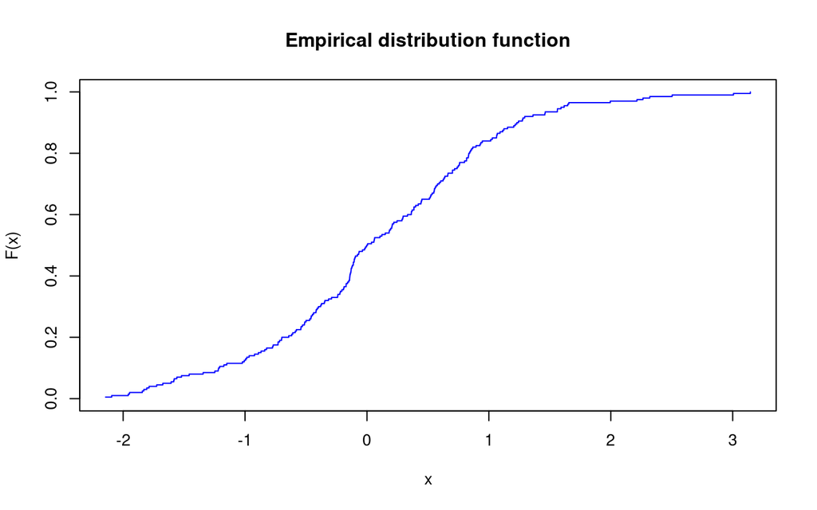

```r
x <- rnorm(200)
x1 <- runif(200, min = 0, max = 10)
cdf <- empirical_cdf(x, plot.cdf = T)
```

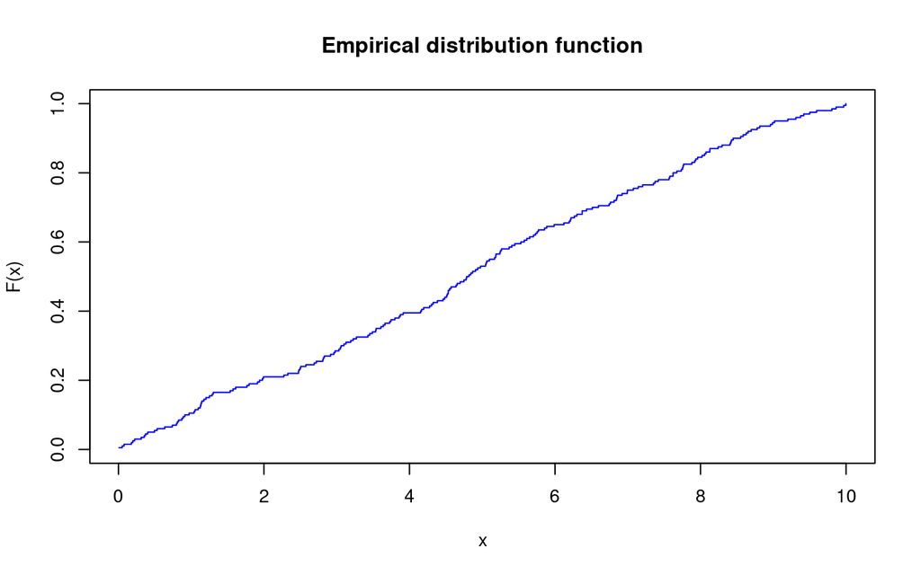

```r
cdf1 <- empirical_cdf(x1, plot.cdf = T)
```

## Hypothesis Testing

Given the following data:

```r
age <- c(64, 95, 28, 64, 62, 54, 92, 96, 86, 69, 102, 75, 33, 33,68, 86, 45, 37, 59, 20, 33, 18, 7, 18, 38, 66, 45, 66, 80, 69, 58, 44, 41, 70, 25, 51, 71, 68, 13, 38)
```

We want to conduct a hypotheses test to determine if the average age is equal to 45 years. Hence, our null hypothesis will be:

$$H_0: \mu = 45$$
While the alternative hypothesis will be:

$$H_1: \mu \neq 45$$
Since one of the assumptions needed to conduct a t-test is that our sample follows a normal distirbution we plot them in a quantile-quantile plot.

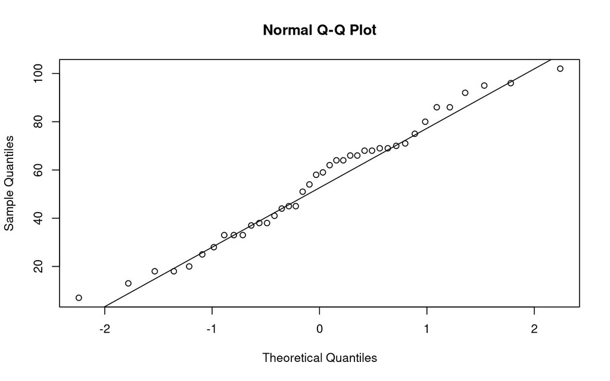

```r
qqnorm(age)
qqline(age)
```

From the graph we can assume that the sample follows a normal distribution. For our t-test we can specify *a priori* a significance level $\alpha$=0.01.

Our test statistic will be:

$$T = \frac{\bar{X} - \mu}{\sqrt{S^2/n}} \sim t_{n-1}$$
We can calculate it using:

```r
n <- length(age)
mu <- 45

# Calculate the t-statistic
t_stat <- (mean(age) - mu)/(sd(age) / sqrt(n))
```

Now that we know both the test statistic and the significance level $\alpha$, we have to check what is the critical value for a t-distribution with $n-1$ degrees of freedom:

```r
alpha <- 0.01
dof <- n - 1
critical_t <- qt(alpha/2, dof, lower.tail = F)
```

Our test statistic is lower than the critical value. Now we can evaluate the $p$-value:

```r
p_val <- 2*pt(-abs(t_stat), df = dof)
```

Since our $p$-value is higher than the fixed significance level $\alpha$, we report that $H_0$ is accepted.

Alternatively, to compute all the values of interest we can use the R function *t.test*:

```r
t_test <- t.test(age, mu = 45, alternative = "two.sided", conf.level = 0.99)
t_test
```

```
##
##  One Sample t-test
##
## data:  age
## t = 2.4647, df = 39, p-value = 0.01822
## alternative hypothesis: true mean is not equal to 45
## 99 percent confidence interval:
##  44.04511 65.30489
## sample estimates:
## mean of x
##    54.675
```

Now we want to plot the density function of the test statistic with the corresponding rejection region.

We plot the density function in the interval [-3,3]. The rejection region of level $\alpha$=0.01 for a t distribution with 39 degrees of liberty and will be:

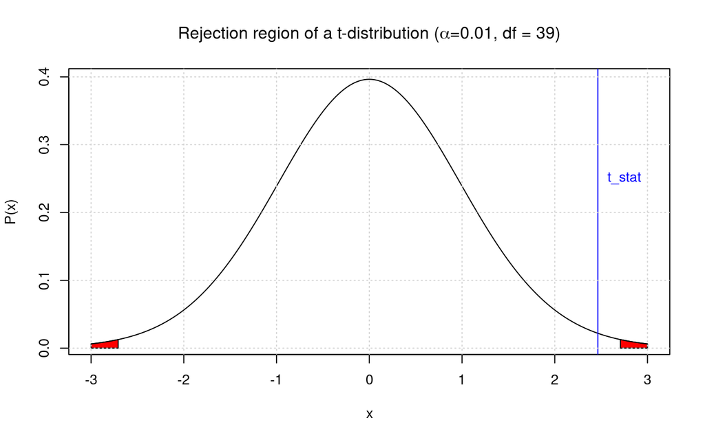

```r
x <- seq(-3,3, length.out = 600)
y <- dt(x,df=39)

# vectors for the rejection region
x_right <- seq(critical_t, 3, length.out = 100)
x_left <- seq(-3, -critical_t, length.out = 100)
y_right <- dt(x_right, df=39)
y_left <- dt(x_left, df=39)

# density plot
plot(x, y, col = 'black', type = 'l', xlab = "x", ylab= "P(x)",
     main = expression(paste("Rejection region of a t-distribution (", alpha, "=0.01, df = 39)")))

# rejection region plot
polygon(c(x_right, max(x_right), min(x_right)), c(y_right, 0, 0), col = 'red')
polygon(c(x_left, max(x_left), min(x_left)), c(y_left, 0, 0), col = 'red')

# plot t_stat
abline(v = t_stat, col = "blue")
text(2.75, 0.25, "t_stat", col = "blue")
grid()
```